# Xoom Cloud Managed Service Agreement Template

**Managed Service Agreement** · Xoom Cloud Pty Ltd

[figure not shown]

> **Strategic IT Partner**

> **Prepared by Vlad Nielsen**

> Prepared on

> 27-May-2025

> The quote is Valid for 30 Days

# Contents

Executive Summary 2

Flexible Support Options: 2

What You Can Expect From Us 3

Security Focused 4

Plan Comparison 5

Proposed Solutions 6

Acceptance 18

Our Standard Rates 19

Service Level Agreement 19

Expectations from Your Commercial Team 20

Terms and Conditions – Managed Services 21

APPENDIX 2 SUPPORT & SERVICE LEVELS 32

## Executive Summary

> In today's rapidly evolving digital landscape, the importance of robust IT solutions cannot be overstated. At Xoom Cloud, we are committed to providing comprehensive Managed IT Services that not only meet but exceed our clients' expectations. Our solutions are designed to enhance operational efficiency, reduce costs, and ensure seamless integration with existing systems.

> A critical component of our Managed IT Services is cybersecurity. We firmly believe that cybersecurity should no longer be considered an optional extra. It is an integral part of our solutions, ensuring that your business is protected against the ever-growing threats in the digital world. Our commitment to cybersecurity is unwavering, and we have integrated it into every aspect of our service offerings.

> By choosing Xoom Cloud as your Managed IT Services provider, you are partnering with a team that prioritises your security and operational success. Let's connect and work together to help your business thrive in the digital age.

## Flexible Support Options:

- **Business Hours Support:** Our team is available during regular business hours to address your IT needs promptly.
- **Extended Support Hours:** For businesses requiring additional support, we offer extended support hours to ensure continuous assistance.
- **24/7 After-hours Support:** Gain peace of mind with round-the-clock support, allowing you to tackle critical IT issues without delays.

## What You Can Expect From Us

- First-quality service and every level of support for your entire IT infrastructure-from basic questions to complex issues-including implementation, user training, integration, remote and onsite service, asset management, and more.
- Experienced, certified technicians, architects and engineers who have deep expertise in solutions to improve the security and performance of your environment.
- System administration, including provisioning, configuring, monitoring, managing, reporting and supporting your infrastructure at the level you choose.
- Flexible support options that enable you to choose the plan that aligns with your business requirements.
- Detailed Service Level Agreements (SLAs) that define expectations.
- Specialist Partners within the industry, each providing specific expert advice on their related technology such as the latest in Security or cloud technologies.

## Security Focused

> **Securing your business with Xoom Cloud to the Essential 8 Framework.**

> In today's digital age, protecting your business from cyber threats is more critical than ever. The Essential 8 framework provides robust strategies to mitigate cybersecurity risks. By leveraging our solutions, you can ensure your business is well-protected across all key areas of the framework.
1. Application Whitelisting Implementing application whitelisting ensures that only approved applications can run on your systems. This prevents unauthorized software from executing, reducing the risk of malware infections and other malicious activities.
2. Patch Applications Regularly updating and patching applications is crucial to protect against known vulnerabilities. Automated patch management solutions can streamline this process, ensuring all software is up-to-date and secure.
3. Configure Microsoft Office Macro Settings Restricting the use of macros in Microsoft Office applications can prevent the execution of malicious code. By configuring macro settings only to allow trusted macros, you can reduce the risk of macro-based attacks.
4. User Application Hardening user applications involves disabling or restricting features that are not necessary for business operations. This includes disabling Flash, ads, and Java, which are common attack vectors.
5. Restrict Administrative Privileges Limiting administrative privileges to only those who need them reduces the risk of unauthorized access and potential damage. Implementing role-based access control and regularly reviewing user permissions are essential steps.
6. Patch Operating Systems: Keeping operating systems up-to-date with the latest patches is vital for maintaining security. Automated patch management solutions can ensure that all systems are regularly updated, minimizing the risk of exploitation.
7. Multi-Factor Authentication (MFA) Implementing MFA adds an extra layer of security by requiring users to provide multiple verification forms before accessing sensitive systems. This significantly reduces the risk of unauthorized access, even if passwords are compromised.
8. Daily Backups: Regularly backing up data ensures you can quickly recover during a cyber incident. Automated backup solutions can streamline this process, ensuring that all critical data is securely backed up and easily recoverable.

> By integrating Xoom Cloud into your business operations, you can quickly start to achieve compliance in the Essential 8 framework and enhance your overall security posture. These measures protect your business from cyber threats and ensure compliance with industry standards and best practices.

## Plan Comparison

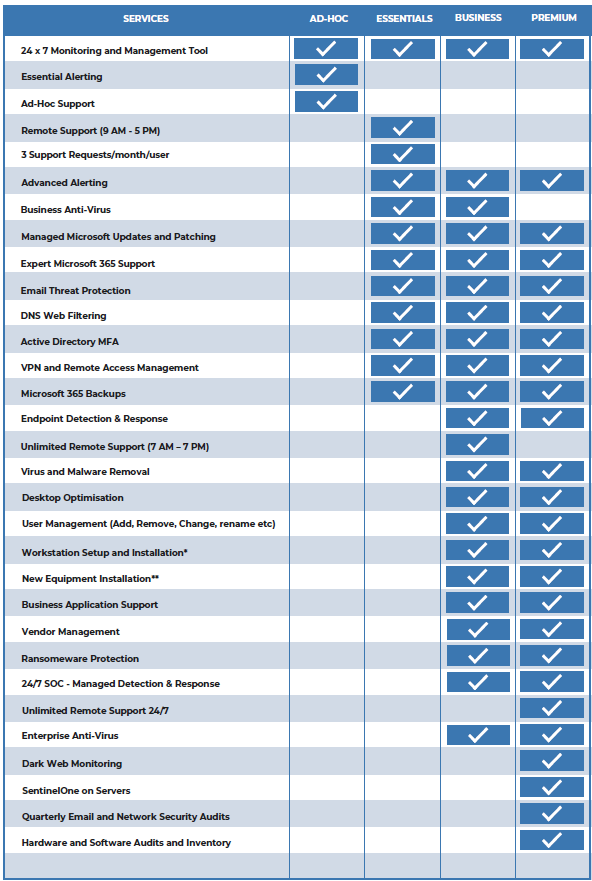

## Acceptance

### Sign Managed Service Agreement

Complete the customer fields, draw or type your signature, then submit the signed agreement.

XoomCloud Pty Ltd trading as XoomAI

ABN

Authorised signatory

Position

Date

Signature (XoomAI)

To be signed by XoomAI upon receipt

Full name *

Position *

Customer *

ABN

Date *

Customer signature *

[interactive chart not shown]

Clear signature

By clicking **Submit Signed Agreement**, you confirm that you have read and agree to be bound by this Managed Service Agreement. A signed PDF will be downloaded and submitted to XoomAI, with a copy sent to the email address below.

Customer email *

## Our Standard Rates

> **Standard Hourly Rates for out-of-scope services**

| **Service** | **Fixed Rate** |
| --- | --- |
| Support Technician (Remote) | $185.00 |
| Support Technician (On Site) | $185.00 (Min 1hr + Travel Cost) |
| Senior Technician | $250.00 |
| Solutions Architect | $280.00 |
| Project Delivery | $450.00 |
| vCIO/Consulting | $280.00 |
| Extended Hours (After Hours) After hour support billed in 15min increments | $450 (min 1hr) |

> All hourly rates are billed in 15min increments unless otherwise stated

## Service Level Agreement

> Performance and Target Response times for our Managed Services, based on the ITIL Principles for support best practice. Service Level Agreements apply to Incidents, Problems, & Service Requests based on the priorities listed below.

| Incident Priority Class | Incident Acknowledgement Time | Target Response Time | Target Resolution Time* |
| --- | --- | --- | --- |
| P1 – Critical | 30 minutes | 2 Hours | 4 Hours |
| P2 – Urgent | 30 minutes | Same Business Day | 1-2 Business Days |
| P3 – Major | 30 minutes | Same Business Day | 2-4 Business Days |
| P4 – Ordinary | 30 minutes | Next Business Day | 2-4 Business Days |
| P5 – Service Request | 1 hour | Next Business Day | 2-5 Business Days |

> * This excludes faults outside of Xoom Cloud's direct control, such as fibre optic or copper cable breaks in the carriage network, power outages at sites not owned and managed by Xoom Cloud and failure of any Customer-owned and operated equipment.

> For the above table, the following priority classifications will apply to the incidents notified:

> **Priority One - Critical:** The customer's ability to conduct core business has stopped.

> **Priority Two - Urgent:** A Key Service or Enterprise Resource is seriously degraded but can continue its operation via a workaround or incremental resource for a short period before business stops.

> **Priority Three - Major:** Access to an Enterprise Resource is lost by a single or small number of users, affecting significant business functionality-problems or incidents where a workaround exists or can be developed with a small number of incremental resources.

> **Priority Four - Ordinary:** Problem or incident where single users can operate the system activities normally, but a definite fault is identified.

> **Priority Five - Service Requests:** Any call from single users or site groups requesting a new service or some clarification on an existing service.

## Expectations from Your Commercial Team

> As your dedicated team, working closely with your technical team, we provide seamless integration of technology solutions within your organisation. Here's what you can expect:
- **Strategic Partnership:** We are your trusted advisor, collaborating closely with your team to understand your business objectives, technical landscape, and long-term vision. Expect strategic discussions that align technology initiatives with your organisational goals..
- **Roadmap Planning:** We don't just focus on the present; we look ahead. Expect a 12 to 24-month roadmap meticulously crafted to meet your evolving needs. This roadmap outlines technology upgrades, enhancements, and optimisations, ensuring your IT investments remain future-proof.
- **Proactive Monitoring and Optimisation:** We continuously monitor your systems, identifying areas for improvement. Expect recommendations for performance optimisation, security enhancements, and scalability.
- **Product Adoption and Training:** We facilitate smooth onboarding for new solutions. They provide training sessions, workshops, and best practices to empower your team.
- **Technical Reviews and Check-Ins:** Regular touchpoints with us ensure ongoing success. Expect proactive discussions about system health, emerging technologies, and industry trends.
- **Issue Resolution and Escalation Management:** The Technical team swiftly addresses challenges when they arise. They escalate critical issues to the right teams, ensuring timely resolution.
- **Thought Leadership and Industry Insights:** Our Team stay informed about industry shifts and shares valuable insights. Expect thought leadership that informs your technology decisions.
- **Customer Satisfaction and Long-Term Partnership:** Beyond technical expertise, we foster trust and collaboration. Our goal? Your satisfaction and sustained success.

> In summary, we are more than a technical expert; we are your strategic navigator in the ever-evolving IT landscape. Let's embark on this journey together!

## Terms and Conditions – Managed Services

> The Supplier will provide managed services to the Customer in accordance with the Managed Services Agreement and in accordance with these Terms and Conditions.

> The Supplier's Master Terms and Conditions apply to this Agreement, which must be accepted when completing an account application with Xoom Cloud.

> (Master Terms and Conditions)

> The Managed Services Agreement is open for acceptance by the Customer for 30 days from the date of issue. This must be signed by the Customer and returned to the Supplier to be accepted by the Customer.
1. Supplier: Contact Details

> Supplier

Xoom Cloud PTY LTD

> Address:

27 Riverland Rd, Coomera, QLD 4209

> Telephone:

1300 040 225

> Primary Contact Person:

Vlad Nielsen, CEO, Xoom Cloud

> Telephone:

0473 567 214

> Email:

Vlad.nielsen@xoomcloud.com.au

2. Customer: Contact Details

> Customer

> Primary Contact Person

> Email
1. **Managed Services**

> Refer to the information above for details of the Managed Services to be provided and related details.
2. **Service Levels**

> Refer to Appendix 2 for details of the Service Levels.

> Support hours (for purposes of services levels) are as follows:

> **Standard Support Hours:**

> **After Hours, for P1 incidents only, are:**

> All other times
3. **Pricing and payment**

> **Managed Services**

> The Managed Services pricing is on basis of:
- per user
- fixed monthly fee
- tiered according to number of users
- the plan that you have selected according to your MSA.

> The Managed Service pricing can be increased but not decreased during the initial term or current renewal term (as applicable).

> Pricing may increase due to increases in numbers of users/devices as described in this Agreement. Pricing may also be increased annually.

| Pricing is in AUD, excluding GST |  |
| --- | --- |
| Monthly Charges: | Monthly in advance |
| Other Charges: | Monthly in arrears |
| Payment Terms | Within 14days following invoice |

> **Price increases**

> At Xoom Cloud's sole discretion, an annual CPI increase or 5% increase (whichever is higher) may be applied on the annual renewal of recurring services agreements.

> At Xoom Cloud's sole discretion, an annual CPI increase or 5% increase (whichever is higher) may be applied on our out-of-scope charge rates. See clause 14.

> Initial Term as specified in the MSA.

> Renewal terms

> Each renewal term has the same duration as the initial term.

> Unless otherwise agreed in writing, this Agreement will renew for a renewal term if:
- the Supplier provides not less than 30 days written notice prior to expiry of the initial term or current renewal term (as applicable) of the upcoming expiry of that term

> **Term**: Unless otherwise agreed in writing, this Agreements will not renew if:
- the Customer confirms in writing to the Supplier not less than 21 days prior to the expiry that they do not wish to renew the Agreement.

> **"After Hours"** (where applicable) means outside of Business Hours; **"Business Hours"** means 8am-6pm on Working Days; QLD time; **"Exception Factors"** means factors described in section 6 of Appendix 1;

> **"Incident"** means an issue in respect of the Managed IT Environment or an issue that the Customer is experiencing in accessing or using the Managed IT Environment (otherwise than due to the user having less than a level of training or knowledge than could be reasonably expected by the Supplier);

> **"Managed IT Environment"** means the customer's IT environment or specified part of it that is managed by the Supplier under the Managed Service, as specified in section 1 of Appendix 1 and as varied under Change Control (refer to section 2 of the Appendix 1);

> **"Managed Services"** means the managed services to be provided to the Customer, as described in section 3 of Appendix 1;

> **"Request for Assistance"** means a request for assistance made by the Customer that is not in connection with an Incident and is not service required as a result of an Exception Factor;

> **"Service Levels"** means the service levels in section 5 of Appendix 2;

> **"Working Day"** means a day other than a Saturday, Sunday or public holiday in QLD.

> **APPENDIX 1 MANAGED SERVICES**
7. **Managed IT Environment**

> a. In Scope (The Managed IT Environment that is In Scope for the Managed Service):

> The Managed Service relates to the third-party products and applications described in the table below in this section 1. The Managed Service does not include a remedy for defective or faulty equipment or components, or failure of third-party services. Where applicable, the Supplier can assist with escalating warranty and defective product/application issues to the relevant third-party supplier.

> The Managed IT Environment is the following items, as approved and confirmed by the Supplier on or prior to Commencement Date. Changes to the Managed IT Environment are made via change control under section 2 below or as agreed in writing between the parties.

> **Component of Managed IT Environment**

> Users' work devices and applications

> Servers and applications

> Network components

> Your line of business applications

> Any changes to the following after Commencement Date must be procured and setup by Supplier or otherwise reviewed and approved by the Supplier. Procuring and setup work, and review/approval work is outside of the scope of this Agreement
- One laptop or desktop computer per user
- One mobile phone per user including VoIP if supplied and installed by Supplier
- Applications on devices that have been approved by Supplier
- Email programs and message delivery
- Windows and security updates
- Antivirus software
- Windows System and Applications
- Application upgrades
- Windows update and patches
- Routers
- Firewalls
- Switches

> Xoom Cloud will provide 1st line support for service requests relating to your third-party vendor systems. We will try to resolve issues where we can. We will escalate it to your third-party vendor directly.

Change Control

1. Changes to the Managed IT Environment will be controlled by email or other written communication between the parties. Where a change to the Managed IT Environment requires a change to the pricing for the Managed Service, that pricing change will be notified by the Supplier to the Customer in writing and will be implemented and charged to the Customer accordingly.

Managed Service Details

1. The Managed Service is as per the Agreement and is provided in relation to the Managed IT Environment except to the extent of Out-of-Scope factors in relation to the Managed IT Environment or the Managed Service, and subject to Customer meeting its obligations under this Agreement and subject also to the Exception Factors.

Type

Managed Service

Managed Service Description

Users

User Support for in Scope

As requested by staff. Refer to Service Requests and Service Levels in sections 1 and 5 of Appendix 2

User Support with e-mail programs and message delivery

As requested by staff. Refer to Service Requests and Service Levels in sections 1 and 5 of Appendix 2

Pro-active machine management

includes the following (additional machine management services may be included as deemed appropriate at Supplier's discretion)

- Disk Space
- Windows and Security updates on users Work device
- Antivirus management
- Temporary File Clean Up

Servers

Remote support tasks required on Windows System and Applications

As per Managed Server Details on Proposal (If applicable)

Application upgrades

As per Managed Server Details on Proposal (If applicable)

Disk space management

As per Managed Server Details on Proposal (If applicable)

Backup monitoring and resolution where issues exist

As per Managed Server Details on Proposal (If applicable)

Backup Testing

As per Managed Server Details on Proposal (If applicable)

Windows update and patch management

As per Managed Server Details on Proposal (If applicable)

Performance Management

As per Managed Server Details on Proposal (If applicable)

1. Third party products and services supplied to Customer:
1. The Managed Service includes supply of third party products and services (listed as 'Provided with Managed Service' in table above, if any). Third party products and services are supplied subject to the relevant third party's terms and conditions which are available on request from the Supplier. By signing this Agreement, the Customer is deemed to accept those third party terms and conditions and the Supplier is authorised to accept the third party terms and conditions on behalf of the Customer when the Supplier procures, installs and/or provides setup services for the Customer in respect of the third party products and services included in the Managed Service.
2. Third party products and services used by Supplier to provide Managed Service: The Supplier uses third party products and services to provide the Managed Service. For some of these third party services (such as remote monitoring and management tools, 'RMM'), an 'agent' is installed on the Customer's devices and other equipment (as applicable). The Customer acknowledges and consents to the use by the Supplier of such third party products and services, including the installation (where applicable) of an agent on the Customer's devices and other equipment. Where the relevant third party supplier's terms and conditions include terms and conditions requiring acceptance by the Customer (including for example to the installation of the agent), by signing this Agreement 1) the Customer is deemed to accept those third party terms and conditions and 2) the Supplier is authorised to accept the third party terms and conditions on behalf of the Customer when the Supplier procures such third party services in respect of the Managed Service to be provided to the Customer and and/or, if applicable, when the Supplier installs the agent on the Customer's devices and other equipment (as applicable) in order to provide the Managed Service.
10. Out of scope

> The following are out of scope for this Managed Service. Where services in relation to the following are provided by the Supplier, the services will be charged at the Supplier's standard rates.
1. Out of scope:
   - Equipment that is not covered by warranty; All or any part of any home networks.
   - Any application on a user's work device not approved by the Supplier.
   - Equipment which is primarily for personal use (not for business purposes).
   - Any machine where the operating system or application is not under support or extended support from the vendor for the Customer.
   - Line of business applications that have no vendor support, or expired support.
2. Data restoration.

> (c) Recovery work following any cyberattack.
4. Services required to investigate, diagnose and/or provide a remedy in relation to external factors.
5. Any work that is required due to an Exception Factor;
6. After Hours Support (unless specifically included in your contract). After Hours Support will be billed at

> $450 per hour, minimum 1 hour charge, and then billed in 15 minute increments;
7. Onsite Support (unless specifically included in your contract). Onsite Support (Field Services) will be billed at $185 per hour, plus travel, minimum 1 hour charge, and then billed in 15 minute increments, plus incidentals such as parking;

> {h) Adds/Moves/Changes which are for small pieces of work, expected to be less than 4 hours of work, which are not covered in the scope of the Managed Services Agreement. For example, migrations. Adds/Moves/Changes will be billed our standard tech rates per hour, billed in 15-minute increments;
1. Project Delivery, for projects that are expected to be 4 or more hours of work, which are not covered in the scope of the Managed Services Agreement. These will be scoped on a separate SOW. Such as but not limited to a new office setup or office move. Project Delivery will be billed at a minimum 1-hour charge, and then billed in 15-minute increments;

> U) Support beyond first line support, for Third Party software, applications or equipment that was not procured by Xoom Cloud;
11. Procurement of new equipment;
    1. Workstation installations and reimaging.
13. Setting up of a new user will be billed as per the fixed fee list.
14. vCIO Consulting
15. The purchase of miscellaneous equipment such as cables.
16. Other ad hoc charges, such as travel costs, travel time, mileage, couriers etc.

Customer responsibilities

> The Customer must:
1. maintain support contracts with all relevant third party suppliers;
2. ensure there is no deliberate damage to any aspect of the Managed IT Environment;
3. notify the Supplier immediately when it becomes aware of any Incident, to prevent further issues.
4. Notify the Supplier of business changes such as the signing of a new lease.

Exception Factors

> The Supplier has no obligation to address or remedy an Incident where the Incident has arisen due to any of the following Exception Factors:

> (a) issues resulting from the Customer's use of infrastructure (including laaS/PaaS), networks, devices, internet connections, software or services where the relevant infrastructure, network, device, software or service is not included in the Managed IT Environment;

> {b) the failure or poor performance of the Customer's power source and/or power supply;
3. any additions, changes or modifications made to the Customer's operating system, environment or equipment except where made or approved by the Supplier;
4. the Customer not acting on a recommendation from the Supplier that additions, changes or updates to the Managed IT Environment are required;
5. changes made by a third-party provider of software, services or equipment;
6. any third party act, omission or circumstance including without limitation any cyberattack or network outage (and including any cyberattack on the systems or services used by the Supplier to provide the Managed Service) which results in unavailability of all or any part of the Managed IT Environment, whether malicious or not (other than where the third party is a subcontractor engaged by the Supplier) or any unauthorised access to the Managed IT Environment;
7. willful damage by any person including without limitation any current or former member of the Customer's staff (employees and/or contractors);
8. any situation, event, system or network outage, defect or other factor (except where the Supplier has directly caused that situation, event, outage, defect, or other factor), which impacts the availability or proper functioning of any component of the Managed IT Environment or the Customer's access to Data, where the impact of that situation, event, outage, defect or other factor is experienced not only by the Customer but also by other businesses and users, including without limitation a Windows update issue, antivirus update issues or system outage by upstream providers; or
9. a Force Majeure Event.

> The Supplier may, at its sole discretion, agree to provide assistance with resolving Incidents that have arisen due to an Exception Factor and if and when it does so:

> U) the work will not be undertaken under this Agreement but under as a separate engagement for a Project under the Professional Services Terms and Conditions and additional charges will apply; and

> (k} the Supplier accepts no responsibility for resolving the issue and the Service Levels in section 5 of Appendix 2 do not apply.
13. **Cybersecurity Services**
    1. Without limiting clause 6 above and notwithstanding that any work in respect of an Exception Factor is to be carried out under a separate agreement and at additional charges, the Customer acknowledges that:
1. if the Supplier undertakes any recovery work following a cybersecurity incident:
   1. recovering from a cybersecurity incident is or may be complex and time-consuming and is dependent on factors which are outside of the control of the Supplier (including successful functioning of the third party security product);
   2. while the Supplier will use its best endeavours on any recovery work, where this work is required the Supplier gives no guarantee that the recovery will be successful or complete;
2. where any ransom is demanded in relation to a ransomware attack, it is the Customer's responsibility to meet that demand and the Supplier has no obligation to and will not meet that ransom demand.
   1. The Customer acknowledges and accepts that the Supplier is not responsible for cybersecurity incidents however caused, including without limitation where the incident is due to any of the following:
1. failure or improper functioning of any third party security product;
2. any unauthorised access to the third party security product;
3. any unauthorised access (including without limitation by the Customer's staff) to the Customer's network, systems, devices, applications, services or data (including but not limited to the systems, devices included in the Managed IT Environment, and related data);
4. Any actions by the customers end users which leads to a security incident;
5. a Force Majeure Event.
14. **Backup failures**
    1. Where the Managed Service includes backup services, the Customer acknowledges that the Supplier is not responsible for backup failures, including without limitation where the failure is due to any of the following:
1. failure or improper functioning of any third party backup service or product;
2. any third party act, omission or circumstance, whether malicious or not (other than where the third party is a subcontractor engaged by the Supplier) or any unauthorised access to the third party backup service or product or to the backed up data;
3. If the customer has their own backup system not provided by Xoom Cloud;
4. a Force Majeure Event.

## APPENDIX 2 SUPPORT & SERVICE LEVELS

15. **Service Requests**

> Making Service Requests: The Customer may make service requests in respect of any Incident as follows:

| Service request logging procedure | Service requests can be logged, for example by phone, email or via our service desk portal |
| --- | --- |
| Telephone request hours | Support hours (for purposes of service levels) are as follow: **Standard Support Hours:** Monday to Friday 8am to 6pm excl Public Holidays QLD time |
| Authorised contact | Authorised contact as specified in the Account Application Form |
| Customer obligations | Customer is to provide a summary of the incidents with as much details as possible, including screenshots where possible. |

16. **Third party involvement**

> The Customer acknowledges that the Supplier may need to work with third parties for resolution of an Incident and the Customer agrees to the Supplier doing so, subject to the position on additional charges in section 3 below.

> Customer's support agreements with other vendors: The Customer is required to maintain current support agreements with all relevant third parties. Where required to resolve an Incident, the Supplier will liaise with the Customer and either work with or hand over the Incident to the relevant third party. On handover, the timing in the Service Levels ceases to apply.
17. **Additional charges**

> Third party vendors or third party products/services: where the Supplier needs to involve the services of a third party vendor or to purchase a third party product or service for resolution of an Incident, an additional charge may apply. The Supplier will provide an estimate for approval by the Customer before incurring the cost, provided that the Customer will not unreasonably withhold approval.
18. **Exclusions**

> The support available under this Appendix does not include services for any issues in respect of Exception Factors, including any issues that in the Supplier's reasonable opinion are due to an Exception Factor.

> The Supplier may, at its sole discretion, agree to provide assistance with resolving issues of the type described in this section 4 and if and when it does so, the Supplier accepts no responsibility for resolving the issue and the Service Levels in section 5 below do not apply. The Supplier may charge the Customer its standard rates for professional services for undertaking any work of the type described in this clause 4 regardless of whether or not the issue is resolved by that work.
19. **Service Levels (SLAs)**

> The response times and target remedy times are within Business Hours only, unless expressly agreed otherwise by the Supplier in writing. Timing ends on escalation to third party support.

> If the Customer has After Hours cover:
- the Supplier provides After Hours service for Priority 1 (P1) issues only);
- if the Customer assigns Priority 1 to an Incident and it is not a P1, the Supplier may charge for the work required to investigate and diagnose the incident at its After Hours' rate
- if a Customer that has After Hours cover requests the Supplier to provide services After Hours for any Incident that is not P1, and the Supplier agrees to provide the required services, the work will be charged at the Supplier's After Hours' rates.

> **Urgency Definitions**

| **High** | Can no longer perform primary work functions |
| --- | --- |
| **Medium** | Work functions impaired, a workaround is in place |
| **Low** | Inconvenient but can still work |

> **Impact Definitions**

| **Company Wide** | A Business Unit, Department or a Site |
| --- | --- |
| **Multiple Users** | Just a small number of users |
| **Single User** | A single user |

> **Ticket Type Definition**

| Ticket Type | Explanation | SLA Applies |
| --- | --- | --- |
| Incident | Any issue affecting normal business operations | Yes – Use Matrix |
| Change Request | A user-initiated change request, desk relocation, new office, moving office, any changes that are not part of the standard business operations. | No |
| Service Request | Onboarding, Offboarding Users, and service requests that are part of the usual business | Yes – P5 |
| Problem | When multiple issues are raised for a single problem, all incidents are merged | Yes - Use Matrix |

> **SLA Response Times**

| Incident Priority Class | Incident Acknowledgement Time | Target Response Time | Target Resolution Time* |
| --- | --- | --- | --- |
| P1 – Critical | 30 minutes | 2 Hours | 4 Hours |
| P2 – Urgent | 30 minutes | Same Business Day | 1-2 Business Days |
| P3 – Major | 30 minutes | Same Business Day | 2-4 Business Days |
| P4 – Ordinary | 30 minutes | Next Business Day | 2-4 Business Days |
| P5 – Service Request | 1 hour | Next Business Day | 2-5 Business Days |